# Problem Set 4

Author

### Instructions

#### How to **complete** this assignment.

- Attempt each exercise in order.
- In each code chunk, if you see “# INSERT CODE HERE”, then you are expected to add some code to create the intended output (Make sure to erase “# INSERT CODE HERE” and place your code in its place).
- If my instructions say to “Run the code below…” then you do not need to add any code to the chunk.
- Many exercises may require you to type some text below the code chunk, interpreting the output and answering the questions.
- Please follow the rules from the course syllabus regarding seeking help with this assignment.

#### How to **submit** this assignment.

- When you are finished, click the “Render” button at the top of this panel. If there are no errors, an HTML file should pop up after a few seconds.
- Take a look at the resulting HTML file that pops up. Make sure everything looks correct, your name is listed at the top, and that there is no ‘junk’ code or output.
- Save the HTML file (to your local computer, and/or to a cloud location) as: **Problem Set 4 “Insert Your Name”**.
- Before you upload the file to HuskyCT, you will need to zip/compress the file.
- Upload the problem set zipped/compressed HTML to HuskyCT. **Do not** upload the original .qmd version.
- This assignment is **due Monday, April 8, 2025, no later than 4:00 pm Eastern**. Points will be deducted for late submissions.
- TIP: Start early so that you can troubleshoot any issues with knitting to HTML.

#### Grading Rubric

There are 8 possible points on this assignment.

**Baseline (C level work)**

- Your .qmd file knits to HTML without errors.
- You answer questions correctly but do not use complete sentences.
- There are typos and ‘junk code’ throughout the document.
- You do not put much thought or effort into the Reflection answers.

**Average (B level work)**

- You use complete sentences to answer questions.
- You attempt every exercise/question.

**Advanced (A level work)**

- Your code is simple and concise.
- Unnecessary messages from R are hidden from being displayed in the HTML.
- Your document is typo-free.
- At the discretion of the instructor, you give exceptionally thoughtful or insightful responses.

##### **(A) Load the appropriate packages, download the data, and take a glimpse of the `QoL Economic Data`. (B) Use tidyverse commands to make a tidy data frame from this sheet, consisting of the number of jobs in each NPA in each year (2002-2015, inclusive) (Hint: Use code to select variables for pivoting; do not just type them all. Convert NPA from a numeric variable to a factor. Additionally, you may have to use dplyr::select in order to make sure that you do not have any function conflicts). (C) Make a table of the NPAs with the 10 highest coefficient of variation (standard deviation / mean) in the number of jobs, giving the NPA number and value of the coefficient of variation. (D) Use a filtering join to make a new data frame consisting of all job number data for those NPAs identified in part (C). (E) Visualize job number volatility using geom_line and one other geom (2 points)**

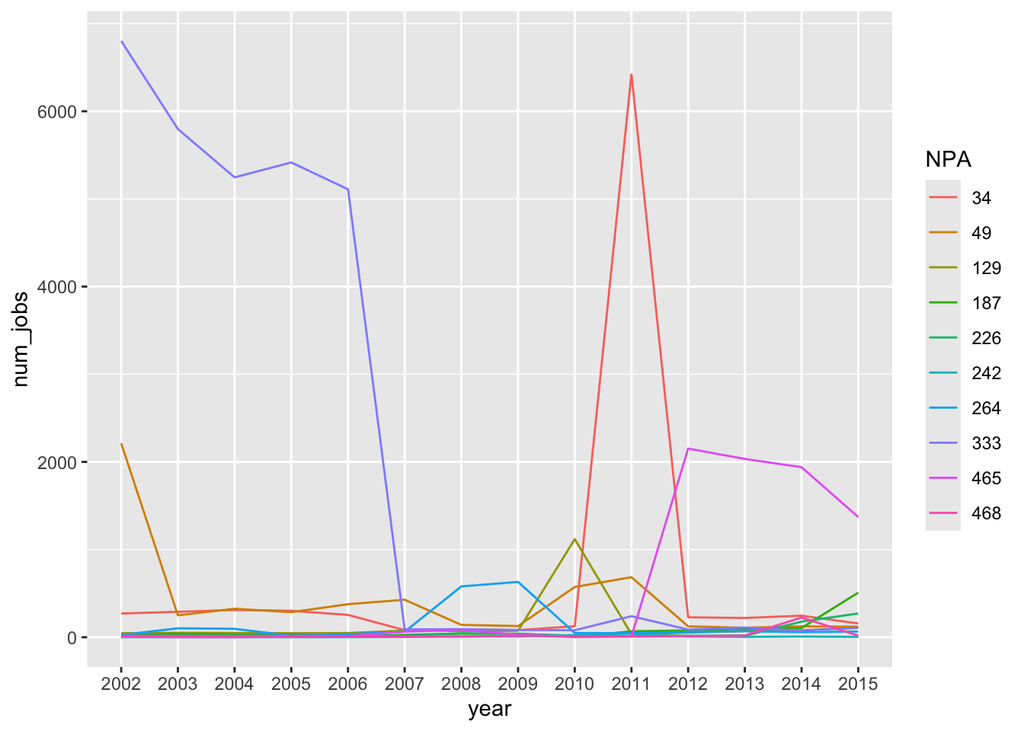

```r
#(A)
library(tidyverse)
library(dplyr)
qol_econ <- read_csv("QoLEconomyData.csv")
#(B)
jobs <- qol_econ %>%
  dplyr::select(NPA, contains("Jobs_")) %>%
  pivot_longer(contains("Jobs_"),
               names_to = "year",
               names_prefix = "Jobs_",
               values_to = "num_jobs") %>%
  mutate(NPA = as.factor(NPA))      #optional

#(C)
#-.1 if break this up into multiple steps (full credit for piping whenever appropriate)
vol <- jobs %>%
    group_by(NPA) %>%
    summarize(sd = sd(num_jobs),
              avg = mean(num_jobs)) %>%
    mutate(cov = sd/avg,
           vol_rank = min_rank(desc(cov))) %>%
    filter(vol_rank <= 10)

#(D)
#Should get 140 observations
vol_jobs <- jobs %>%
  semi_join(vol)
#(E)
#Line graph and box plot are two best ways to show this
#one of them must be geom_line
vol_jobs %>%
  ggplot(aes(x=year, y = num_jobs, group = NPA, color = NPA)) +
  geom_line()
```

[output not shown]

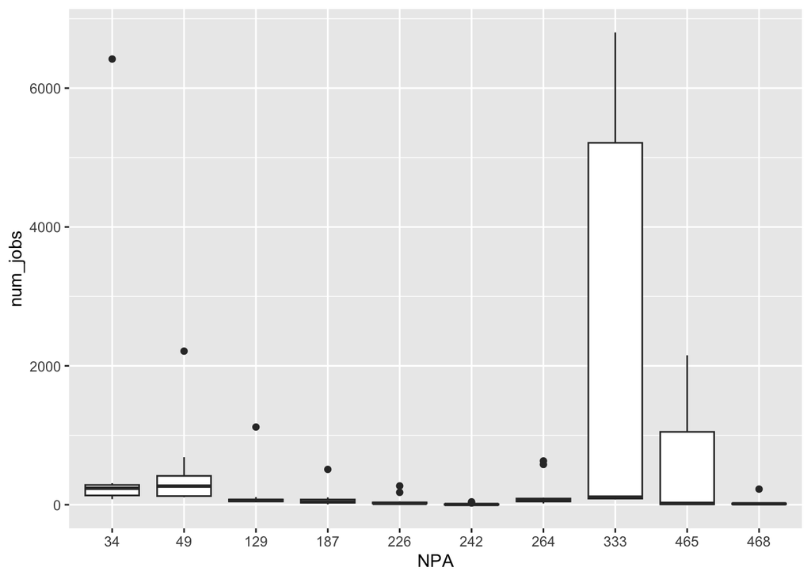

```r
vol_jobs %>%
  ggplot(aes(x=NPA, y = num_jobs, group = NPA)) +
  geom_boxplot()
```

**ANSWER:**

##### **Exercise 2. (A) Using the `QoL Housing Data` and following a similar process to that in Exercise 1, construct a data frame consisting of the number of housing units in each NPA in each year for which data is available. Combine the two data frames in two ways: (B) including all values from both data frames and (C) including only those years for which both jobs and housing units data are available. (D) Tabulate the number of NPAs with and without missing data in each year for each of these two combined data frames. (2 points)**

```r
#(A)
qol_housing <- read_csv("QoLHousingData.csv")
glimpse(qol_housing)
```

```
Rows: 463
Columns: 135
$ NPA                                      <dbl> 2, 3, 4, 5, 6, 7, 8, 9, 10, 1…
$ Housing_Density_2019                     <dbl> 2.62, 7.08, 1.25, 2.06, 1.98,…
$ Housing_Units_2019                       <dbl> 1077, 8183, 410, 345, 798, 42…
$ Housing_Density_2018                     <dbl> 2.6, 5.1, 1.3, 1.9, 2.0, 0.8,…
$ Housing_Units_2018                       <dbl> 1083, 5931, 419, 318, 808, 43…
$ Housing_Density_2017                     <dbl> 2.6, 4.6, 1.2, 1.9, 2.0, 0.8,…
$ Housing_Units_2017                       <dbl> 1079, 5283, 408, 322, 813, 43…
$ Housing_Density_2016                     <dbl> 2.6, 4.1, 1.2, 2.0, 2.0, 0.8,…
$ Housing_Units_2016                       <dbl> 1079, 4730, 406, 326, 816, 42…
$ Housing_Density_2015                     <dbl> 2.6, 4.1, 1.2, 2.0, 2.0, 0.8,…
$ Housing_Units_2015                       <dbl> 1079, 4752, 404, 331, 817, 42…
$ Housing_Density_2013                     <dbl> 2.6, 4.1, 1.2, 2.0, 2.0, 0.8,…
$ Housing_Units_2013                       <dbl> 1081, 4746, 402, 329, 820, 42…
```

[output cut: 122 more lines]

```r
housing <- qol_housing %>%
  dplyr::select(NPA, starts_with("Housing_Units")) %>%
  pivot_longer(-NPA,
               names_to = "year",
               names_prefix = "Housing_Units_",
               values_to = "housing") %>%
  mutate(NPA = as.factor(NPA))    #optional

#(B)
all <- jobs %>%
  full_join(housing)
#(C)
both <- jobs %>%
  inner_join(housing)
#(D)
# one way to show missingness -- other ways are acceptable

all %>%
  group_by(year) %>%
  summarize(missing = sum(is.na(housing) | is.na(num_jobs)),
            nonmissing = n() - missing)
```

```
# A tibble: 18 × 3
   year  missing nonmissing
   <chr>   <int>      <int>
 1 2002      462          0
 2 2003      462          0
 3 2004      462          0
 4 2005      462          0
 5 2006      462          0
 6 2007      462          0
 7 2008      462          0
 8 2009      462          0
 9 2010      462          0
10 2011        1        462
11 2012      462          0
12 2013        1        462
13 2014      462          0
14 2015        1        462
15 2016      463          0
16 2017      463          0
17 2018      463          0
18 2019      463          0
```

```r
both %>%
  group_by(year) %>%
  summarize(missing = sum(is.na(housing) | is.na(num_jobs)),
            nonmissing = n() - missing)
```

```
# A tibble: 3 × 3
  year  missing nonmissing
  <chr>   <int>      <int>
1 2011        0        462
2 2013        0        462
3 2015        0        462
```

**ANSWER:**

##### **Exercise 3. (A) Load the `Cross Walk Data` (Hint: If you get an error, then try read.csv()), the `Chetty Data`, and the `NC ECE Data`. (B) Use the data file `Cross Walk Data` (which matches counties to CZs) and the `Chetty data` file to add CZ name, relative mobility, and absolute mobility variables to the data frame `NC ECE Data`. (C) Use the modified `NC ECE` data frame to visualize the distribution of QRIS points in each CZ in North Carolina in the year 2014. (2 points)**

```r
#(A)
cw <- read.csv("Cross Walk Data.csv")
mobility <- read_csv("Chetty_2014.csv")
ece <- read_csv("NC ECE Data.csv")
#(B)
#common mistake is not filtering to NC, and getting matches to same county names in different states
#-.1 for not showing data frames
(mob_county <- cw %>%
  filter(stateabbrv == "NC") %>%
  left_join(mobility) %>%
  dplyr::select(rel_mobility, abs_mobility, cz_name, county_name))
```

```
    rel_mobility abs_mobility          cz_name  county_name
1              0           36       Greensboro     Alamance
2              0           36          Hickory    Alexander
3              0           41            Galax    Alleghany
4              0           36        Charlotte        Anson
5              0           38 North Wilkesboro         Ashe
6              0           40            Boone        Avery
7              0           38       Washington     Beaufort
8              0           36   Roanoke Rapids       Bertie
9              0           36       Wilmington       Bladen
10             0           36       Wilmington    Brunswick
11             0           39        Asheville     Buncombe
12             0           38        Morganton        Burke
13             0           36        Charlotte     Cabarrus
14             0           36          Hickory     Caldwell
```

[output cut: 86 more lines]

```r
(ece_plus <- ece %>%
  left_join(mob_county, by = c("county" = "county_name")))
```

```
# A tibble: 64,297 × 31
   id        year fname      ftype license agerange city  county subregion   zip
   <chr>    <dbl> <chr>      <chr> <chr>   <chr>    <chr> <chr>  <chr>     <dbl>
 1 00000004  2010 YANCEY CO… Head… Star R… 3-6      Burn… Yancey Yancey    28714
 2 00000004  2009 YANCEY CO… Head… Star R… 3-6      Burn… Yancey Yancey    28714
 3 00000004  2012 YANCEY CO… Head… Star R… 3-6      Burn… Yancey Yancey    28714
 4 00000004  2014 YANCEY CO… Head… Star R… 3-6      Burn… Yancey Yancey    28714
 5 00000004  2007 YANCEY CO… Head… Star R… 3-6      Burn… Yancey Yancey    28714
 6 00000004  2011 YANCEY CO… Head… Star R… 3-6      Burn… Yancey Yancey    28714
 7 00000004  2013 YANCEY CO… Head… Star R… 3-6      Burn… Yancey Yancey    28714
 8 00000004  2008 YANCEY CO… Head… Star R… 3-6      Burn… Yancey Yancey    28714
 9 00000018  2011 KIDZ FIRS… Inde… Star R… 0-12     Burn… Yancey Yancey    28714
10 00000018  2009 KIDZ FIRS… Inde… Star R… 0-12     Burn… Yancey Yancey    28714
# ℹ 64,287 more rows
# ℹ 21 more variables: center_based <chr>, capacity <dbl>, enroll <dbl>,
#   enroll_1yr <dbl>, enroll_2yr <dbl>, enroll_3yr <dbl>, enroll_4yr <dbl>,
#   enroll_5yr <dbl>, QRIS_rating <chr>, QRIS_points <dbl>,
#   QRIS_edu_score <dbl>, QRIS_pgm_score <dbl>, QRIS_qual_pt <chr>,
#   QRIS_ERS <dbl>, p_pov <dbl>, p_black <dbl>, p_hisp <dbl>, med_income <dbl>,
#   rel_mobility <dbl>, abs_mobility <dbl>, cz_name <chr>
```

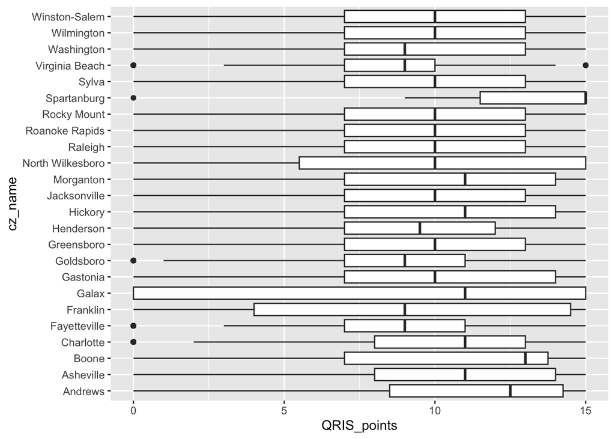

```r
#(C)
#need to use coord_flip (-.2 if they do not)
ece_plus %>%
  filter(year == 2014) %>%
  ggplot(aes(x=cz_name, y = QRIS_points)) +
  geom_boxplot() +
  coord_flip()
```

**ANSWER:**